# Assignment on Factors

Damilare Olaleye

2/27/2020

```r
library(LearnBayes)
```

Assignment on Factors

The dataset studentdata in the LearnBayes package contains measurements from 657 students in an introductory statistics class.

```r
head(studentdata)
```

```
##   Student Height Gender Shoes Number Dvds ToSleep WakeUp Haircut  Job
## 1       1     67 female    10      5   10    -2.5    5.5      60 30.0
## 2       2     64 female    20      7    5     1.5    8.0       0 20.0
## 3       3     61 female    12      2    6    -1.5    7.5      48  0.0
## 4       4     61 female     3      6   40     2.0    8.5      10  0.0
## 5       5     70   male     4      5    6     0.0    9.0      15 17.5
## 6       6     63 female    NA      3    5     1.0    8.5      25  0.0
##   Drink
## 1 water
## 2   pop
## 3  milk
## 4 water
## 5   pop
## 6 water
```

1. Examine the factor variable Drink. Find the values, levels of this variable.

```r
drink_variable = data.frame(studentdata)
str(drink_variable['Drink'])
```

```
## 'data.frame':    657 obs. of  1 variable:
##  $ Drink: Factor w/ 3 levels "milk","pop","water": 3 2 1 3 2 3 3 2 3 1 ...
```

2. Try replacing the first value of Drink to “tea”. You should get an error? Fix this so you don’t get an error?

```r
#This displays an error
#drink_variable[1] = "tea"
#drink_variable

#drink_variable$m.Drink = with(drink_variable,drink_variable="tea",stringsAsFactros=F)

drink_variable$Drink = (factor(drink_variable$Drink, levels = c("milk","pop","water","tea")))
levels(as.factor(drink_variable$Drink))
```

```
## [1] "milk"  "pop"   "water" "tea"
```

```r
drink_variable$Drink[1] = 'tea'
head(drink_variable['Drink'])
```

```
##   Drink
## 1   tea
## 2   pop
## 3  milk
## 4 water
## 5   pop
## 6 water
```

3. Using the tapply function, find the median number of pairs of shoes owned by men and women.

```r
using_tapply <- with(drink_variable[complete.cases(drink_variable),], tapply(Shoes, Gender, median))
using_tapply
```

```
## female   male
##  17.75   5.00
```

4. Using the tapply function, find the median number of pairs of shoes owned by students classified by gender and favorite drink.

```r
classfier_tapply <- with(drink_variable[complete.cases(drink_variable),], tapply(Shoes, list(Drink, Gender), median))
classfier_tapply
```

```
##       female male
## milk    15.0  5.5
## pop     16.5  5.0
## water   20.0  5.0
## tea     10.0   NA
```

5. Using the split function, split the student heights in two groups by gender – store the output in the variable Heights.

```r
Heights <- with(drink_variable[complete.cases(drink_variable), ], split(Height, Gender))
head(Heights)
```

```
## $female
##   [1] 67.00 64.00 61.00 61.00 61.00 64.00 66.00 63.00 63.50 65.00 64.00
##  [12] 61.00 56.00 63.00 65.00 64.00 59.00 61.50 64.00 63.00 66.00 66.00
##  [23] 63.00 67.00 76.00 61.00 63.00 62.00 65.00 68.00 63.00 62.00 66.00
##  [34] 62.00 67.00 64.50 66.00 65.00 65.00 67.00 64.00 67.00 64.00 66.00
##  [45] 65.00 64.00 68.00 62.00 55.00 68.00 62.00 62.00 61.00 68.00 60.00
##  [56] 68.00 56.00 67.00 69.00 72.00 76.00 64.00 72.00 66.00 63.00 63.00
##  [67] 64.00 69.00 54.00 64.00 62.00 64.00 64.00 64.50 61.00 69.00 64.00
##  [78] 62.00 68.00 64.50 67.00 62.00 66.00 67.00 66.00 67.00 64.00 67.00
##  [89] 54.00 60.00 63.00 63.00 64.00 65.00 67.00 62.00 66.00 67.00 64.00
## [100] 68.00 64.00 63.00 64.00 71.00 61.00 58.50 66.50 66.00 64.00 60.00
## [111] 65.00 63.00 69.00 66.00 67.00 62.00 67.00 67.00 64.00 67.00 64.00
## [122] 64.00 64.00 66.00 65.50 63.00 63.00 68.00 67.00 69.00 60.00 62.00
## [133] 68.00 69.00 61.00 66.00 70.00 71.00 66.00 67.00 62.00 62.00 64.00
## [144] 70.00 65.50 62.50 84.00 60.00 62.00 65.00 60.00 67.50 64.00 73.00
```

[output cut: 40 more lines]

6. Using the lapply function, find the maximum height for each gender. (By the way, there is some missing values, so you will have to remove them by the na.rm = TRUE option.) Are you surprised by the answer? Why?

```r
lapply(Heights, max)
```

```
## $female
## [1] 84
##
## $male
## [1] 79
```

7. Construct a bar graph of the Drink variable.

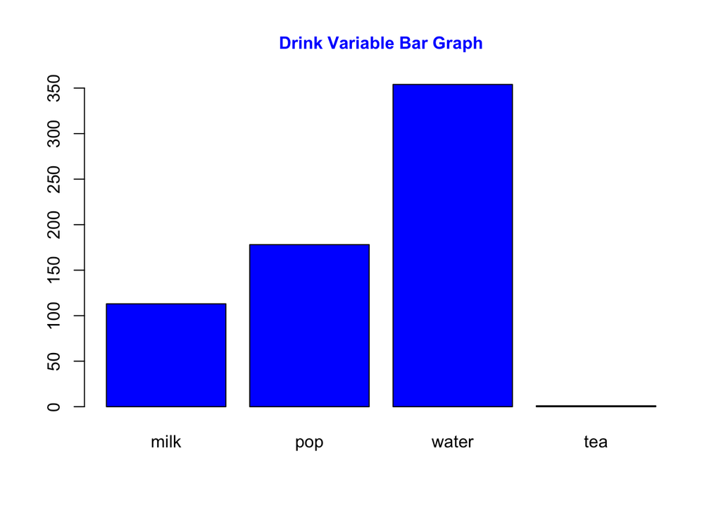

```r
barplot(main="Drink Variable Bar Graph",cex.main=1,col="blue",col.main="blue",table(drink_variable$Drink))
```

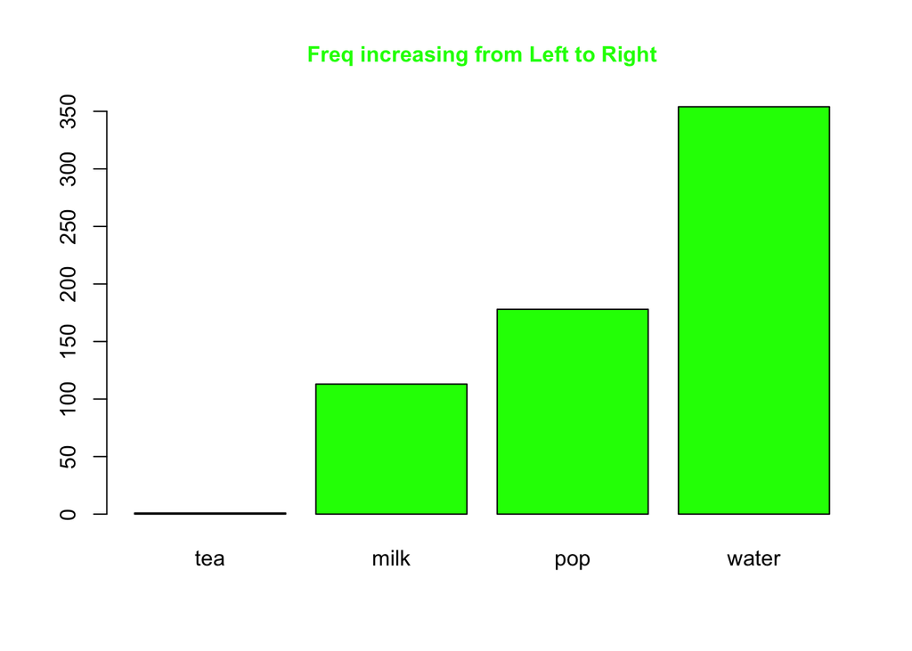

```r
drink_variable$Drink = (factor(drink_variable$Drink, levels = c("tea","milk","pop","water")))
barplot(main="Freq increasing from Left to Right",cex.main=1,col.main="green",col= "green",table(drink_variable$Drink))
```

9. Use the table function to tabulate all of the students by Gender and Drink choice.

```r
table(list(drink_variable$Gender, drink_variable$Drink))
```

```
##         .2
## .1       tea milk pop water
##   female   1   63 110   255
##   male     0   50  68    99
```

10. By using the prop.table() function, find the proportion of men who prefer milk and the proportion of women who prefer milk.

```r
prop.table(table(list(drink_variable$Gender, drink_variable$Drink))[,4])
```

```
##   female     male
## 0.720339 0.279661
```

11. Define a new variable Sleep in the studentdata data frame that is equal to the difference in the WakeUp and ToSleep times.

```r
drink_variable['Sleep'] = drink_variable$WakeUp - drink_variable$ToSleep
drink_variable$Sleep
```

```
##   [1]  8.00  6.50  9.00  6.50  9.00  7.50  6.00  7.00  7.50  6.00  6.50
##  [12]  8.00  4.00  8.50  6.00  7.50  8.50  5.50  7.00  9.00  6.50  6.00
##  [23]  7.00  8.00  9.00  6.50  7.50  8.50  8.00  7.00  8.00  6.00  7.00
##  [34]  8.50  8.00  6.00  8.50  5.25  7.00 10.00  8.00 10.00  7.00 10.50
##  [45]  7.50  5.00  5.50  7.50  8.00  9.00  7.50  9.50  7.00  7.00  7.00
##  [56]  9.00  8.00  7.00  8.50  8.00  8.00  7.00  6.00  6.00  8.50  9.00
##  [67]  6.00  9.00 11.00  8.00  5.50  5.50  5.00  8.00  9.00  7.50 10.50
##  [78]  5.00 11.00  3.50  9.50  6.00  9.00  4.50  8.00  9.50  7.00  7.50
##  [89]  5.00  6.50  8.50  7.50  8.00  5.50  7.00  7.50  7.50  7.00  6.50
## [100]  6.50  8.00  6.50  5.50  5.00  7.00  7.00  6.00  4.00  8.00  9.50
## [111]  9.00  7.50  8.50  6.00  8.00  8.00  6.00  6.50  6.00  6.50  8.50
## [122]  7.50  6.50  5.50  5.00  7.00  7.00  7.00  6.00    NA  8.00  7.00
## [133]  3.50  6.50  8.00  6.00  4.50  6.50 10.50  7.00  8.50  8.50  6.00
## [144]  6.50  8.00  6.00  8.00  6.50  6.00  6.00  8.00  6.50  7.00  7.50
## [155]  9.00  7.00  8.00  9.50  5.00  5.00  7.00  7.00  7.00  8.00  8.00
```

[output cut: 45 more lines]

12. What is the mean amount of sleep of these students?

```r
mean_amt <- mean(drink_variable$Sleep, na.rm = T)
mean_amt
```

```
## [1] 7.385191
```

13. Use the cut function to classify students as Light or Heavy sleepers if they get less than or more than 7.5 hours of sleep respectively – call the new variable CSleep.

```r
drink_variable['CSleep'] <- cut(drink_variable$Sleep, breaks = c(-Inf,7.5, Inf), labels = c('Light','Heavy'))
```

14. Use the table function to classify all students by Gender, Drink choice, and CSleep.

```r
classfiy_students <- table(list(drink_variable$Gender, drink_variable$Drink, drink_variable$CSleep))
classfiy_students
```

```
## , , .3 = Light
##
##         .2
## .1       tea milk pop water
##   female   0   33  67   152
##   male     0   31  37    53
##
## , , .3 = Heavy
##
##         .2
## .1       tea milk pop water
##   female   1   30  42   102
##   male     0   19  30    45
```

15. Graph the counts in the table constructed in 14.

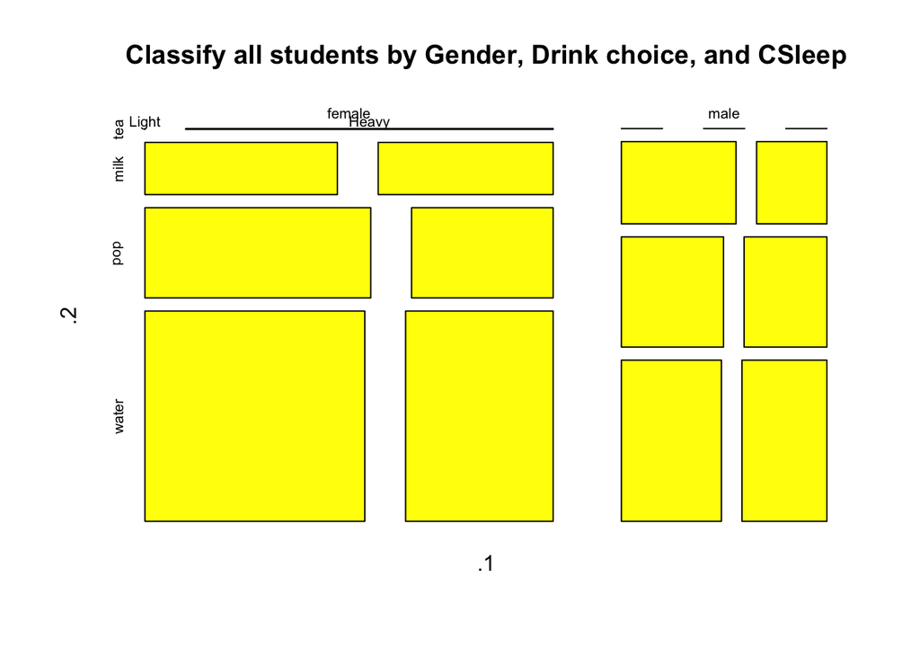

```r
plot(main="Classify all students by Gender, Drink choice, and CSleep",col="yellow",classfiy_students)
```

16. Using the apply function three times, find the three marginal tables of Gender by Drink, Gender by CSleep,and Drink by CSleep.

```r
apply(table(drink_variable$Gender, drink_variable$Drink), 1, sum)
```

```
## female   male
##    429    217
```

```r
apply(table(drink_variable$Gender, drink_variable$CSleep), 1, sum)
```

```
## female   male
##    433    220
```

```r
apply(table(drink_variable$Drink, drink_variable$Sleep), 1, sum)
```

```
##   tea  milk   pop water
##     1   113   176   352
```

17. By using code, identify the combination of (Gender, Drink, CSleep) that has the highest frequency.

```r
highest_freq<-data.frame(table(drink_variable$Gender, drink_variable$Drink, drink_variable$CSleep))
 highest_freq[highest_freq$Freq == max(highest_freq$Freq), ]
```

```
##     Var1  Var2  Var3 Freq
## 7 female water Light  152
```